# Unplanned Analysis: Standardized Effect Sizes

Athos

December 02, 2019

```r
# Load the four data files and only keep the useful columns
prolific_export = read_csv(paste0(exp1_datapath, "prolific_export.csv")) %>%
  select(participant_id,
         entered_code,
         time_taken,
         age,
         country = `Current Country of Residence`,
         sex = Sex)

results = read_csv(paste0(exp1_datapath, "results.csv")) %>%
  select(participant_id,
         fund_allocation_southeast_asia = fundAllocation_UNHCR,
         fund_allocation_middle_east = fundAllocation_IOM,
         donation_allocation_southeast_asia = donationAllocation) %>%
  mutate(fund_allocation_difference = fund_allocation_southeast_asia - fund_allocation_middle_east)

excluded = read_csv(paste0(exp1_datapath, "excluded.csv")) %>%
  select(participant_id,
         failed_attention_check,
         reloaded) %>%
  mutate(participant_id = as.character(participant_id)) # necessary if all are NAs

agreed = read_csv(paste0(exp1_datapath, "all_who_agreed.csv")) %>%
  select(participant_id,
         condition)

# Join the four datasets and clean up a bit
data_all = agreed %>%
  left_join(excluded, by = "participant_id") %>%
  left_join(prolific_export, by = "participant_id") %>%
  full_join(results, by = "participant_id") %>%
  subset(!participant_id %in% exclude_participant_ids) %>%
  mutate(failed_attention_check = coalesce(failed_attention_check, 0), # replace NAs with zeros
         reloaded = coalesce(reloaded, 0))

# Clean up possibly serious anomalies in the data and issue warnings if necessary
data_all_original = data_all
data_all = data_all %>%
  drop_na(participant_id, condition) %>%
  distinct(participant_id, .keep_all= TRUE)
# if (nrow(data_all) != nrow(data_all_original)) {
#   cat("WARNING -- Data has duplicate participants, missing participant IDs, or missing conditions:")
#   anti_join(data_all_original, data_all)
# }

# Create another dataset with completed submissions only
exp1_data = data_all %>%
  filter(entered_code == exp1_completion_code)

# Split datasets according to the condition
data_all_rich_first = data_all %>% filter(condition == "richFirst")
data_all_poor_first = data_all %>% filter(condition == "poorFirst")
data_rich_first = exp1_data %>% filter(condition == "richFirst")
data_poor_first = exp1_data %>% filter(condition == "poorFirst")
```

```r
# Load the four data files and only keep the useful columns
prolific_export = read_csv(paste0(exp2_datapath, "prolific_export.csv")) %>%
         dplyr::select(participant_id,
         entered_code,
         time_taken,
         age,
         country = `Current Country of Residence`,
         sex = Sex)

results = read_csv(paste0(exp2_datapath, "results.csv")) %>%
  dplyr::select(participant_id,
         donation,
         valence,
         arousal
         ) %>%
  mutate(donation = 100 - donation) # Donation for cause B

excluded = read_csv(paste0(exp2_datapath, "excluded.csv")) %>%
  dplyr::select(participant_id,
         failed_attention_check,
         reloaded) %>%
  mutate(participant_id = as.character(participant_id)) # necessary if all are NAs

agreed = read_csv(paste0(exp2_datapath, "all_who_agreed.csv")) %>%
  dplyr::select(participant_id,
         condition,
         design,
         identity)

# Join the four datasets and clean up a bit
data_all = agreed %>%
  left_join(excluded, by = "participant_id") %>%
  left_join(prolific_export, by = "participant_id") %>%
  full_join(results, by = "participant_id") %>%
  subset(!participant_id %in% exclude_participant_ids) %>%
  mutate(failed_attention_check = coalesce(failed_attention_check, 0), # replace NAs with zeros
         reloaded = coalesce(reloaded, 0)) %>%
  mutate(
    identity = case_when(
      identity == "NonAnonymous" ~ "Named",
      identity == "Anonymous" ~ identity
    ),
    design = case_when(
      design == "Anthropographic" ~ "Rich",
      design == "NonAnthropographic" ~ "Poor"
    ),
    condition = paste(identity, design, sep = "_")
  )

# Clean up possibly serious anomalies in the data and issue warnings if necessary
data_all_original = data_all
data_all = data_all %>%
  drop_na(participant_id, condition) %>%
  distinct(participant_id, .keep_all= TRUE)
if (nrow(data_all) != nrow(data_all_original)) {
  cat("WARNING -- Found duplicate participant IDs or data with missing participant ID or missing condition. This data was discarded:")
  anti_join(data_all_original, data_all)
}

# Create another dataset with completed submissions only
exp2_data = data_all %>% dplyr::filter(entered_code == exp2_completion_code)

# Clean up possibly serious anomalies in the data and issue warnings if necessary
data_original = exp2_data
exp2_data = exp2_data %>%
  drop_na(donation, valence, arousal)
if (nrow(exp2_data) != nrow(data_original)) {
  cat("WARNING -- Found completed submissions with missing DVs (donation, valence or arousal). This data was discarded:")
  anti_join(data_original, exp2_data)
}

# Split datasets according to the condition
data_all_ar = data_all %>% dplyr::filter(condition == "Anonymous_Rich")
data_all_ap = data_all %>% dplyr::filter(condition == "Anonymous_Poor")
data_all_nr = data_all %>% dplyr::filter(condition == "Named_Rich")
data_all_np = data_all %>% dplyr::filter(condition == "Named_Poor")

data_ar = exp2_data %>% dplyr::filter(condition == "Anonymous_Rich")
data_ap = exp2_data %>% dplyr::filter(condition == "Anonymous_Poor")
data_nr = exp2_data %>% dplyr::filter(condition == "Named_Rich")
data_np = exp2_data %>% dplyr::filter(condition == "Named_Poor")
```

```
## WARNING -- Found duplicate participant IDs or data with missing participant ID or missing condition. This data was discarded:
```

| participant_id | condition | design | identity | failed_attention_check | reloaded | entered_code | time_taken | age | country | sex | donation | valence | arousal |
| --- | --- | --- | --- | --- | --- | --- | --- | --- | --- | --- | --- | --- | --- |
| 5d926642c46d560019b5ec73 | Anonymous_Poor | Poor | Anonymous | 0 | 0 | 6B23E247 | 502 | 25 | NA | Female | 57 | 0 | 0 |
| 5cd07e08db3fce00135afd9c | Named_Poor | Poor | Named | 0 | 1 | NA | 7079 | 22 | CONSENT REVOKED | CONSENT REVOKED | NA | NA | NA |
| 5dc2bd90569be31d76ca69b3 | Named_Rich | Rich | Named | 0 | 1 | NOCODE | 531 | 41 | NA | Male | NA | NA | NA |
| 5dc2bd90569be31d76ca69b3 | Named_Rich | Rich | Named | 0 | 1 | NOCODE | 531 | 41 | NA | Male | NA | NA | NA |

```
## WARNING -- Found completed submissions with missing DVs (donation, valence or arousal). This data was discarded:
```

| participant_id | condition | design | identity | failed_attention_check | reloaded | entered_code | time_taken | age | country | sex | donation | valence | arousal |
| --- | --- | --- | --- | --- | --- | --- | --- | --- | --- | --- | --- | --- | --- |
| 5d3f70024d9d2b00178113c2 | Anonymous_Poor | Poor | Anonymous | 0 | 0 | 6B23E247 | 332 | 28 | Poland | Female | NA | NA | NA |
| 5d4a077a879721001ade6dff | Anonymous_Poor | Poor | Anonymous | 0 | 0 | 6B23E247 | 566 | 63 | United Kingdom | Female | NA | NA | NA |

# 1 Data

The experiment had 4 conditions:

```r
exp2_data %>%
  count(condition)
```

| condition | n |
| --- | --- |
| Anonymous_Poor | 207 |
| Anonymous_Rich | 196 |
| Named_Poor | 188 |
| Named_Rich | 195 |

We use Cohen’s *d* and probability of superiority as standardized effect sizes. We interpret the effect sizes based on the work of Lakens (2013).

- Lakens, D. (2013). Calculating and reporting effect sizes to facilitate cumulative science: a practical primer for t-tests and ANOVAs. Frontiers in psychology, 4, 863.

# 2 Primary effect of experiment 2

**DV1** = mean donation allocation to cause B (migrants in need helped by UNHCR) [Range: 0, 100]

**effect 1** = Cohen’s *d* between DV1 in information-rich conditions (both anonymous and named) and DV1 in information-poor conditions (both anonymous and named)

```r
# DV1 in Rich conditions
exp2_DV1_r = exp2_data %>%
  dplyr::filter(design == "Rich") %>%
  dplyr::pull(donation)

# DV1 in Poor conditions
exp2_DV1_p = exp2_data %>%
  dplyr::filter(design == "Poor") %>%
  dplyr::pull(donation)

exp2_effect1.d = cohen.d(exp2_DV1_r, exp2_DV1_p)
exp2_effect1.ps = ps(exp2_effect1.d)

print_effect("Cohen's d", exp2_effect1.d)
print_effect("Probability of superiority", exp2_effect1.ps, plot = F)
```

```
## Cohen's d :  0.14, 95% CI [-0.0011, 0.28]
## Probability of superiority :  0.54, 95% CI [0.5, 0.58]
```

There is a 53.92% probability that an individual allocated more funds when s/he saw the information-rich visualization than the poor one.

# 3 Experiment 2 vs. Experiment 1

In the following, we show standardized effect sizes from experiment 1.

**DV1** = standardized mean difference between funds allocated to the rich visualization and the poor visualization

```r
DV1_rich = c(data_rich_first %>% pull(fund_allocation_southeast_asia),
             data_poor_first %>% pull(fund_allocation_middle_east))
DV1_poor = c(data_rich_first %>% pull(fund_allocation_middle_east),
             data_poor_first %>% pull(fund_allocation_southeast_asia))
effect1.d = cohen.d(DV1_rich, DV1_poor)
effect1.ps = ps(effect1.d)

print_effect("Cohen's d", effect1.d)
print_effect("Probability of superiority", effect1.ps, plot = F)
```

```
## Cohen's d :  0.12, 95% CI [-0.13, 0.37]
## Probability of superiority :  0.53, 95% CI [0.46, 0.6]
```

**DV2** = Percentage of global UNHCR funds allocated to SouthEast Asia (the rest being allocated to other parts of the world)

```r
DV2_rich = data_rich_first %>% pull(fund_allocation_southeast_asia)
DV2_poor = data_poor_first %>% pull(fund_allocation_southeast_asia)
effect2.d = cohen.d(DV2_rich, DV2_poor)
effect2.ps = ps(effect2.d)

print_effect("Cohen's d", effect2.d)
print_effect("Probability of superiority", effect2.ps, plot = F)
```

```
## Cohen's d :  0.18, 95% CI [-0.17, 0.53]
## Probability of superiority :  0.55, 95% CI [0.45, 0.65]
```

**DV3** = Percentage of personal money donated to the rich visualization compared to the amount donated to the poor visualization scenario

```r
DV3_rich = c(data_rich_first %>% pull(donation_allocation_southeast_asia),
             data_poor_first %>%
               mutate(donation_allocation_middle_east = 100 - donation_allocation_southeast_asia) %>%
               pull(donation_allocation_middle_east))
DV3_poor = c(data_rich_first %>%
               mutate(donation_allocation_middle_east = 100 - donation_allocation_southeast_asia) %>%
               pull(donation_allocation_middle_east),
             data_poor_first %>% pull(donation_allocation_southeast_asia))
effect3.d = cohen.d(DV3_rich, DV3_poor)
effect3.ps = ps(effect3.d)

print_effect("Cohen's d", effect3.d)
print_effect("Probability of superiority", effect3.ps, plot = F)
```

```
## Cohen's d :  -0.12, 95% CI [-0.37, 0.13]
## Probability of superiority :  0.47, 95% CI [0.4, 0.54]
```

The following chat corresponds to the primary effect of experiment 2 and the three effects of experiment 1, respectively.

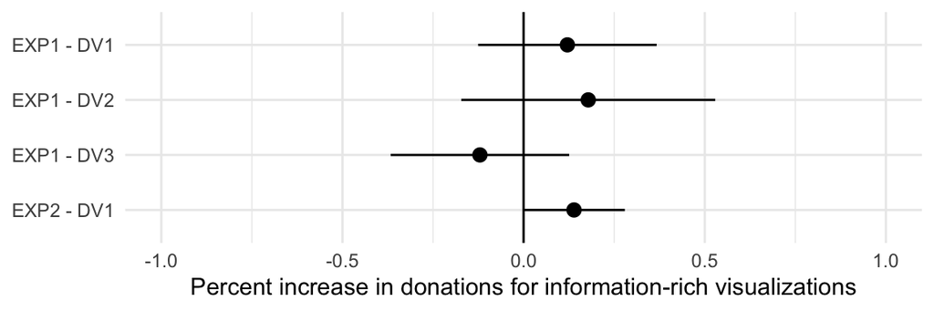

```r
plotAllCIs(lim = c(-1, 1), xlabel = "Percent increase in donations for information-rich visualizations", ylabel = NULL, yreorder = c(2,3,4,1), ylabels = c("EXP1 - DV1","EXP1 - DV2","EXP1 - DV3","EXP2 - DV1"))
```

```r
ggsave(filename = "../../../paper-figures/standardized-effects.pdf", dpi = 300, width = 6, height = 2)
```